# script_scarabi

## R Markdown

```r
library(Seurat)
library(tximport)

samps <- c("SRR8257100",
"SRR8257101",
"SRR8257102",
"SRR8257103",
"SRR8257104",
"SRR8257105",
"SRR8257106")
```

# path to the output directory of Alevin quant run

```r
files <- file.path(
  paste("~/mydatalocal/tpngsscarabi_lena/data/quant/",samps,"/alevin/quants_mat.gz", sep=""))
file.exists(files)
```

```
## [1] TRUE TRUE TRUE TRUE TRUE TRUE TRUE
```

```r
txis <- lapply(files, function(f) tximport(files = f, type="alevin"))
```

[output not shown]

[output not shown]

[output not shown]

[output not shown]

[output not shown]

[output not shown]

[output not shown]

[output not shown]

[output not shown]

[output not shown]

[output not shown]

[output not shown]

[output not shown]

[output not shown]

# Il faut créer 4 objets Seurat indépendants pour les 4 échantillons de WT

On ne peut pas les compiler plus tôt car ils proviennent d’expériences indépendantes et donc peuvent contenir les mêmes identifiants. Il faut donc les séparer et on les mergera ensuite.

avec min.cells = 3 on retire les gènes exprimés dans moins de 3 cellules

avec min.features = 200 on retire les cellules exprimant moins de 200 gènes

avec add.cell.ids = samps[1:4] on rend chaque cellule identifiée de manière unique

```r
 s1 <- CreateSeuratObject(counts = txis[[1]]$counts , min.cells = 3, min.features = 200, project = samps[1])
 s2 <- CreateSeuratObject(counts = txis[[2]]$counts , min.cells = 3, min.features = 200, project = samps[2])
 s3 <- CreateSeuratObject(counts = txis[[3]]$counts , min.cells = 3, min.features = 200, project = samps[3])
 s4 <- CreateSeuratObject(counts = txis[[4]]$counts , min.cells = 3, min.features = 200, project = samps[4])
scarabiWT <- merge(s1, y = c(s2, s3,s4), add.cell.ids = samps[1:4], project = "scarabiWT")
```

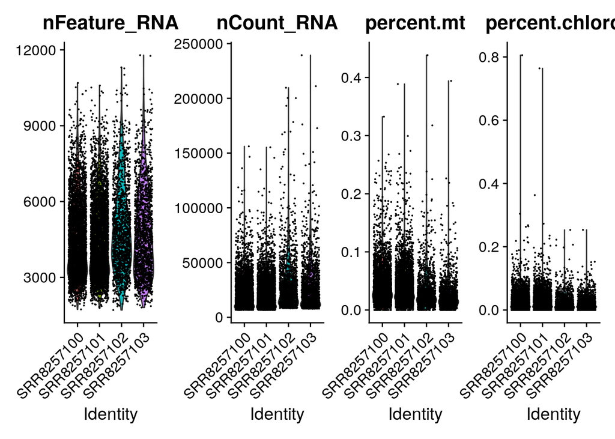

```r
scarabiWT[["percent.mt"]] <- PercentageFeatureSet(scarabiWT, pattern = "ATM")
scarabiWT[["percent.chloro"]] <- PercentageFeatureSet(scarabiWT, pattern = "ATC")

 VlnPlot(scarabiWT, features = c("nFeature_RNA", "nCount_RNA", "percent.mt", "percent.chloro"), ncol = 4)
```

On remarque ici que les échantillons 100 et 101 ont anormalement beaucoup de gènes mitochondriaux et chloroplastiques : il faut qu’on sélectionne les cellules qui n’ont pas trop souffert. Il serait intéressant de retirer les 5% de cellules les plus “mauvaises”, avec le plus le gènes mitochondriaux exprimés; et mettre une valeur à 0.2 pour les chloroplastiques.

```r
thr_mt <- quantile(scarabiWT[["percent.mt"]]$percent.m, 0.95)
thr_chloro <- scarabiWT[["percent.chloro"]]<0.2

scarabiWT_filter <- subset(scarabiWT, subset = percent.chloro < 0.2 & percent.mt < thr_mt )
```

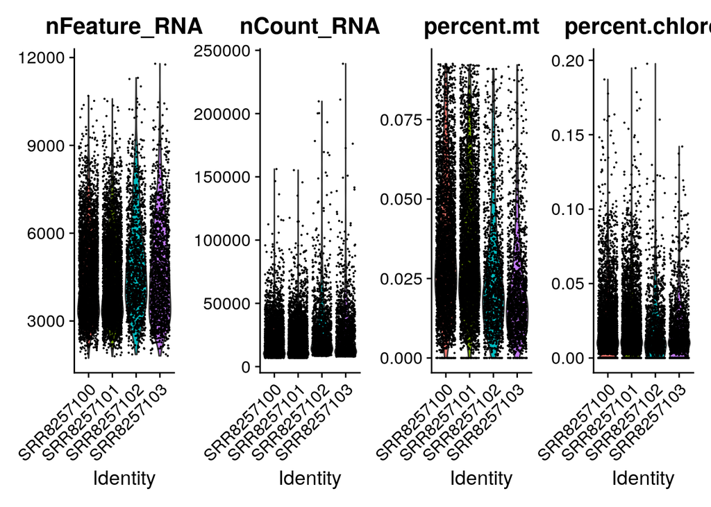

```r
VlnPlot(scarabiWT_filter, features = c("nFeature_RNA", "nCount_RNA", "percent.mt", "percent.chloro"), ncol = 4)
```

Avec l’affiche de scarabiWT_filter, on voit que nous travaillons maintenant avec 11321 cellules, et 23443 gènes. ( Avant le filtre, on travaillait avec 11920 et 23443 gènes )

Pour avoir plus de détails sur le nombre de cellules contenues par échantillon : table(scarabiWT$orig.ident)

#Il faut maintenant normaliser les données L’objectif est que la médiane d’expression entre les quatre echantillons soit la même, tout en gardant les rapports d’expression au sein de chaque échantillon; pour comparer ce qui est comparable.

```r
scarabiWT_filter <- NormalizeData(scarabiWT_filter, normalization.method = "LogNormalize", scale.factor = 10000)
```

Ne pas s’intéresser aux gènes dont l’expression ne varie pas, ni aux gènes de “bruit”. Le choix du nfeatures est légèrement difficile, on se met souvent à 10% du nombre de gènes totaux. Ici on va d’abord essayer avec 10 000 gènes, et on ajustera si nécessaire.

```r
scarabiWT_filter <- FindVariableFeatures(scarabiWT_filter, selection.method = "vst", nfeatures = 10000)

# plot variable features with and without labels
top10 <- head(VariableFeatures(scarabiWT_filter), 10)
plot1 <- VariableFeaturePlot(scarabiWT_filter)
plot2 <- LabelPoints(plot = plot1, points = top10, repel = TRUE)
```

```
## When using repel, set xnudge and ynudge to 0 for optimal results
```

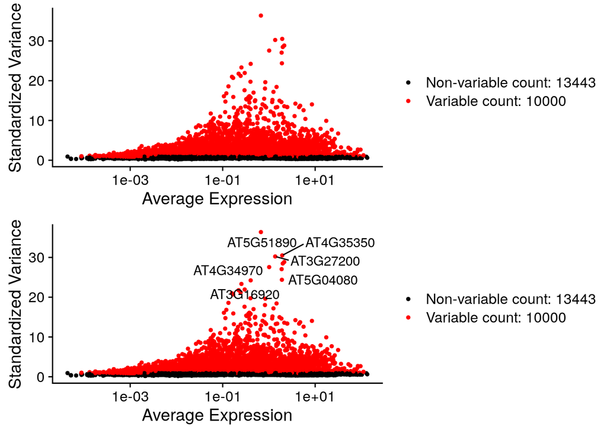

```r
CombinePlots(plots = list(plot1, plot2),nrow=2)
```

On fait maintenant une transformation linéaire :

```r
all.genes <- rownames(scarabiWT_filter)
scarabiWT_filter <- ScaleData(scarabiWT_filter, features = all.genes)
```

On fait maintenant la PCA: (l’UMAP se basera sur la PCA)

```r
scarabiWT_filter <- RunPCA(scarabiWT_filter, features = VariableFeatures(object = scarabiWT_filter))
```

[output not shown]

```r
print(scarabiWT_filter[["pca"]], dims = 1:5, nfeatures = 5)
```

```
## PC_ 1
## Positive:  AT4G21980, AT5G44020, AT5G60660, AT2G31570, AT1G62660
## Negative:  AT5G02960, AT5G20290, AT3G25520, AT5G15200, AT3G04400
## PC_ 2
## Positive:  AT4G34050, AT5G56540, AT1G75750, AT3G53420, AT3G49780
## Negative:  AT1G13950, AT2G32380, AT5G26260, AT3G06300, AT5G40510
## PC_ 3
## Positive:  AT2G30395, AT2G27080, AT2G31350, AT4G27350, AT5G24310
## Negative:  AT4G21850, AT5G02260, AT5G47990, AT5G19340, AT3G09940
## PC_ 4
## Positive:  AT5G10430, AT1G04820, AT5G53250, AT3G18780, AT4G35100
## Negative:  AT1G07590, AT3G19660, AT1G78000, AT5G07440, AT3G25597
## PC_ 5
## Positive:  AT3G32980, AT1G72630, AT2G14900, AT3G22600, AT2G32300
## Negative:  AT3G53620, AT2G15830, AT3G51670, AT1G12780, AT3G25597
```

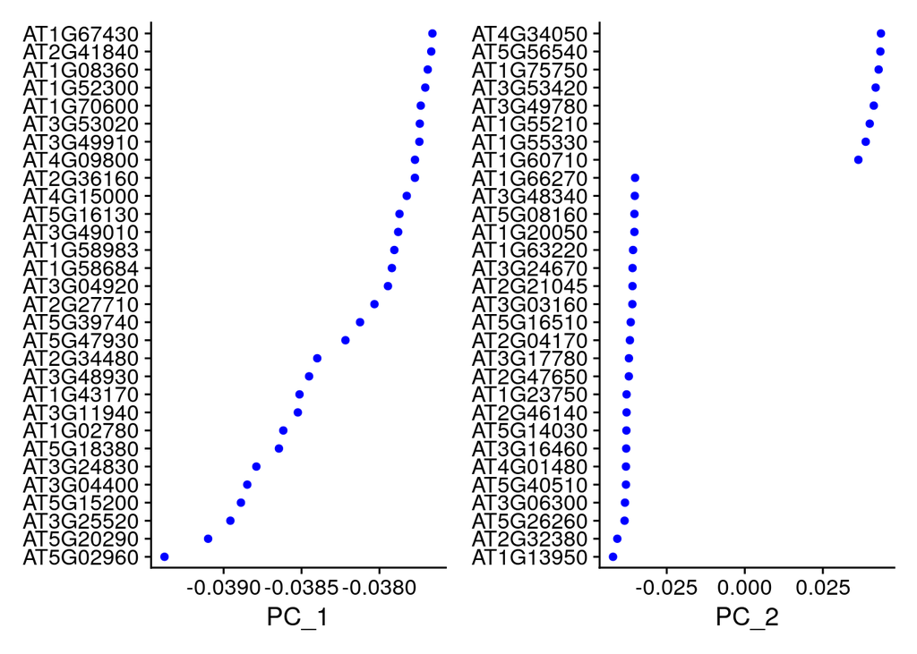

```r
VizDimLoadings(scarabiWT_filter, dims = 1:2, reduction = "pca")
```

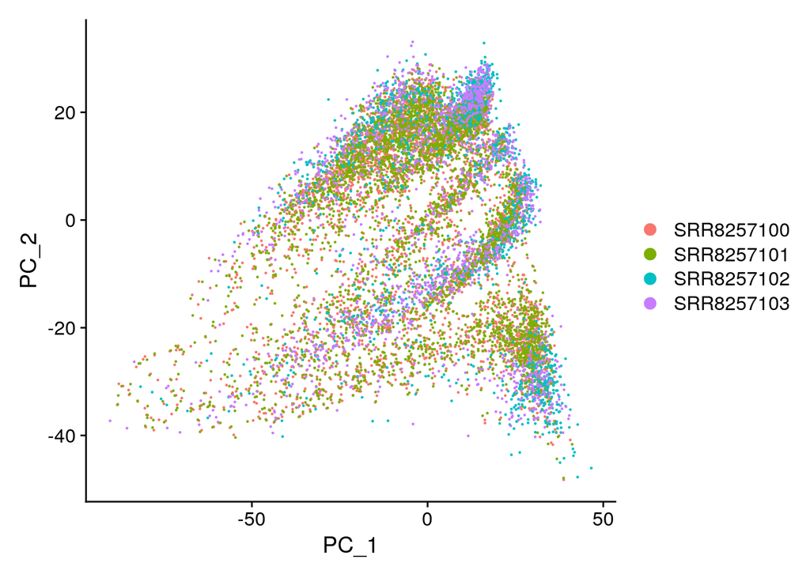

```r
DimPlot(scarabiWT_filter, reduction = "pca")
```

La PCA donne des axes qui expliquent au mieux la variance du jeu de données. Les axes sont des combinaisons linéaires des gènes de départ, avec des poids différents.

On peut maintenant faire des Heat Maps d’expression des gènes :

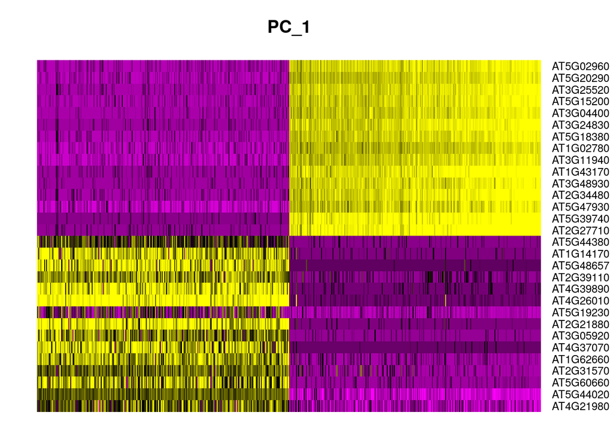

```r
DimHeatmap(scarabiWT_filter, dims = 1, cells = 500, balanced = TRUE)
```

```r
#on représente les 500 cellules avec le plus de variations d'expression
```

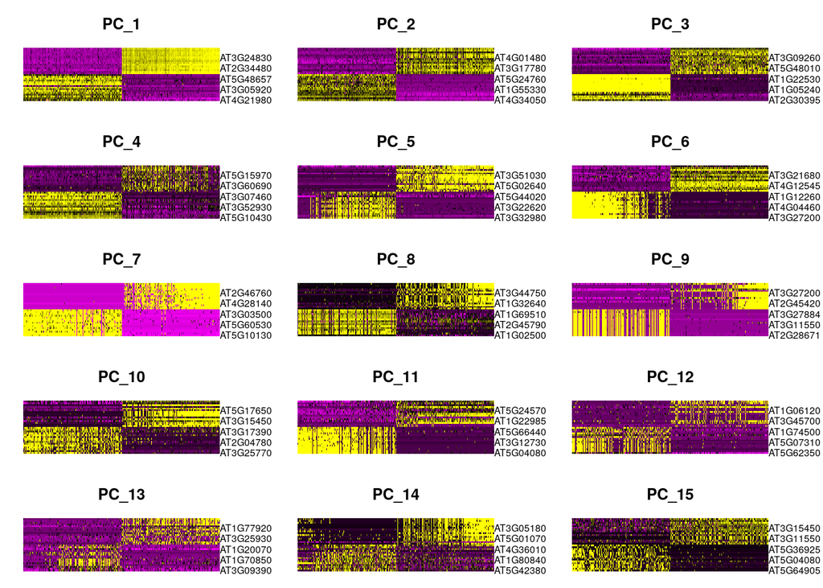

```r
DimHeatmap(scarabiWT_filter, dims = 1:15, cells = 500, balanced = TRUE)
```

Là on visualise selon les 15 premiers axes : on remarque que très vite les axes ne représentent plus tant que ça la variance de l’expression. Cela peut notamment être expliqué par le fait que certains gènes co-varient (sont co-régulés), donc peuvent expliquer la variation selon un même axe.

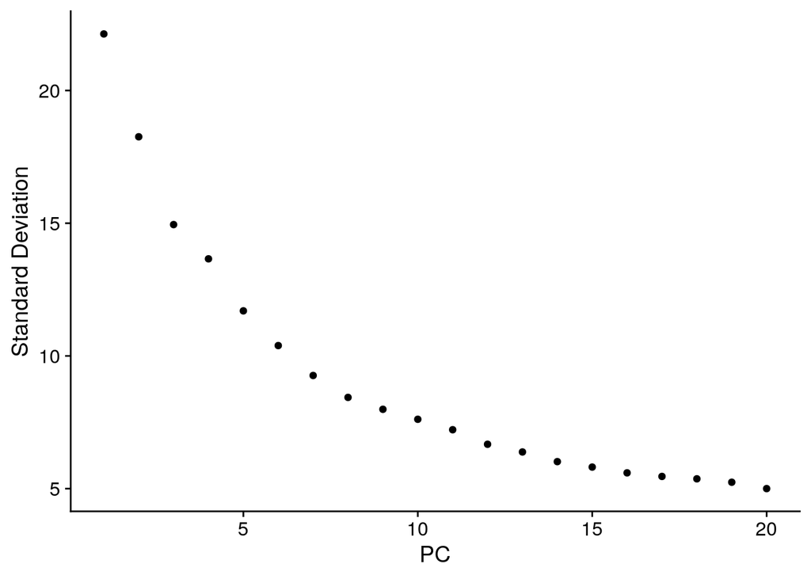

```r
ElbowPlot(scarabiWT_filter)
```

On cherche d’abord les voisins, puis les clusters

```r
scarabiWT_filter <- FindNeighbors(scarabiWT_filter, dims = 1:10)
scarabiWT_filter <- FindClusters(scarabiWT_filter, resolution = 0.5)
```

```
## Modularity Optimizer version 1.3.0 by Ludo Waltman and Nees Jan van Eck
##
## Number of nodes: 11321
## Number of edges: 342307
##
## Running Louvain algorithm...
## Maximum modularity in 10 random starts: 0.9435
## Number of communities: 18
## Elapsed time: 0 seconds
```

```r
head(Idents(scarabiWT_filter), 5)
```

```
## SRR8257100_CCACTACCAAGTTGTC SRR8257100_CGAATGTTCAGGTAAA
##                          10                          14
## SRR8257100_AAGGAGCAGAGGGCTT SRR8257100_ACCTTTAAGGACCACA
##                          14                          14
## SRR8257100_TGAGCATCAATCTGCA
##                          10
## Levels: 0 1 2 3 4 5 6 7 8 9 10 11 12 13 14 15 16 17
```

L’UMAP essaie de projeter sans trop perdre l’information : garder les clusters de cellules avec des expressions voisines; et garder la distance entre les clusters

```r
scarabiWT_filter <- RunUMAP(scarabiWT_filter, dims = 1:10)
```

UMAP constructs a high dimensional graph representation of the data then optimizes a low-dimensional graph to be as structurally similar as possible. L’UMAP calcule des distances euclidiennes entre cellules.

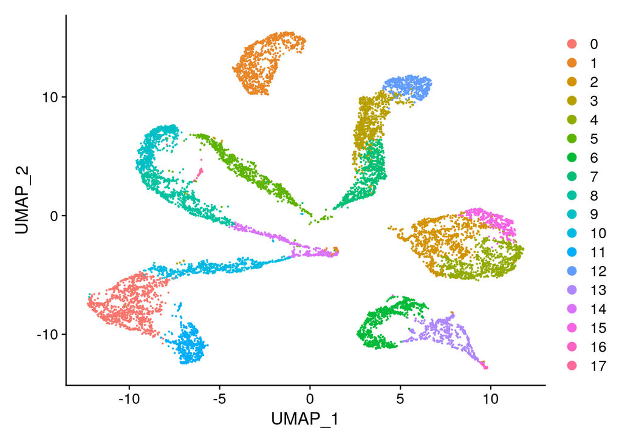

```r
DimPlot(scarabiWT_filter, reduction = "umap")
```